# R Workshop Day 3: Objects, Tables, and Plots

Mike Burnham

03 August, 2022

|  | docketId | caseId | docket | justice | petitioner_vote | petitioner_pitch | respondent_pitch | lcDispositionDirection | justiceName | lagged_ideology | petitioner_dal_pos | petitioner_wc | respondent_dal_pos | respondent_wc | petitioner_dal_neg | respondent_dal_neg | petitioner_count | respondent_count | petac | respac | petNumStat | respNumStat | sgrespac | sgpetac | petitioner_harvard_pos | respondent_harvard_pos | petitioner_harvard_neg | respondent_harvard_neg | petitioner_liwc_pos | … |
| --- | --- | --- | --- | --- | --- | --- | --- | --- | --- | --- | --- | --- | --- | --- | --- | --- | --- | --- | --- | --- | --- | --- | --- | --- | --- | --- | --- | --- | --- | --- |
| 1 | 1982-038-01 | 1982-038 | 81-1802 | 104 | 1 | 0.098386471 | 0.5470785160 | 2 | SDOConnor | 1.491 | 3 | 60 | 0 | 58 | 1 | 0 | 2 | 2 | 0 | 0 | 10 | 3 | 0 | 0 | 2 | 1 | 0 | 1 | 3 | … |
| 2 | 1982-038-01 | 1982-038 | 81-1802 | 102 | 1 | -0.548233386 | -0.3921478376 | 2 | WHRehnquist | 4.036 | 2 | 100 | 2 | 102 | 0 | 1 | 1 | 5 | 0 | 0 | 10 | 3 | 0 | 0 | 5 | 7 | 3 | 3 | 2 | … |
| 3 | 1982-038-01 | 1982-038 | 81-1802 | 99 | 1 | -1.329199988 | -0.8811175139 | 2 | WEBurger | 1.491 | 1 | 70 | 10 | 477 | 0 | 2 | 6 | 17 | 0 | 0 | 10 | 3 | 0 | 0 | 4 | 18 | 1 | 8 | 1 | … |
| 4 | 1982-038-01 | 1982-038 | 81-1802 | 103 | 1 | -0.327294623 | 0.0310757928 | 2 | JPStevens | -0.265 | 2 | 134 | 2 | 126 | 2 | 1 | 3 | 2 | 0 | 0 | 10 | 3 | 0 | 0 | 5 | 7 | 1 | 2 | 2 | … |
| 5 | 1982-038-01 | 1982-038 | 81-1802 | 98 | 1 | 0.008951913 | -0.0116924967 | 2 | TMarshall | -3.684 | 0 | 12 | 3 | 61 | 1 | 0 | 2 | 2 | 0 | 0 | 10 | 3 | 0 | 0 | 0 | 4 | 1 | 2 | 0 | … |
| 6 | 1982-080-01 | 1982-080 | 81-1463 | 99 | 1 | -2.437310363 | -0.6017832603 | 2 | WEBurger | 1.491 | 0 | 2 | 1 | 4 | 0 | 0 | 1 | 1 | 0 | 0 | 10 | 3 | 0 | 0 | 0 | 1 | 0 | 0 | 0 | … |
| 7 | 1982-085-01 | 1982-085 | 81-1891 | 99 | 1 | -0.645410701 | -1.2230248808 | 2 | WEBurger | 1.491 | 0 | 2 | 0 | 9 | 0 | 0 | 1 | 2 | 5 | 0 | 7 | 6 | 0 | 0 | 0 | 0 | 0 | 0 | 0 | … |
| 8 | 1982-088-01 | 1982-088 | 81-1476 | 99 | 1 | -0.850971527 | 0.1906808445 | 1 | WEBurger | 1.491 | 0 | 18 | 2 | 35 | 2 | 0 | 1 | 1 | 0 | 0 | 10 | 3 | 0 | 0 | 0 | 3 | 1 | 2 | 0 | … |
| 9 | 1982-091-01 | 1982-091 | 81-2125 | 99 | 1 | -0.980726843 | 1.9305876666 | 1 | WEBurger | 1.491 | 0 | 7 | 1 | 6 | 0 | 0 | 1 | 2 | 1 | 3 | 10 | 9 | 0 | 0 | 0 | 1 | 0 | 0 | 0 | … |
| 10 | 1982-092-01 | 1982-092 | 82-185 | 99 | 1 | 2.620762000 | 7.3082863505 | 2 | WEBurger | 1.491 | 0 | 9 | 0 | 2 | 0 | 0 | 2 | 1 | 6 | 8 | 4 | 2 | 0 | 1 | 0 | 0 | 0 | 0 | 0 | … |

[output cut: 990 more lines]

# 1 Objects

Everything in R is an **object.** We won’t worry about the technical definition of an object, but all you need to know is that objects can be used to store and manipulate data and have **attributes**. Attributes are used for storing and organizing the features of an object.

```r
attributes(df) # you will rarely, if ever, use this function. This is for illustrative purposes

# So if we call the names attribute of the df object it will return the vectors within that attribute
names(df)
```

You will probably never do object oriented programming in R, but having a conceptual idea of what they are and how to examine or manipulate their attributes will help with some of the most common tasks in R.

# 2 Models

One of the ways that R speeds up analysis is by offering functions that work with complicated objects. A good example of this is how we work with model objects.

```r
# to create a model, use the GLM function. Let's look at the documentation
?glm()

# So we need to specify a formula and a model family
# let's start by creating a formula
eq1 <- petitioner_vote ~ lagged_ideology + pitch_diff + petitioner_liwc_neg + petitioner_count + conservative_lc

# now let's call the glm function and specify a model family
md1 <- glm(eq1, family = binomial)

# We get an error message, why? Is there an object "petitioner vote" in our global environment?
# there is no object "petitioner_vote". There is a vector called petitioner_vote in our data frame, however, so we can specify that
md1 <- glm(eq1, family = binomial, data = df)
# lets see what is in our model object
attributes(md1)
```

There are several functions in R that work with model objects. The two you will probably use most often are summary() and plot()

```r
summary(md1)
```

```
Call:
glm(formula = eq1, family = binomial, data = df)

Deviance Residuals:
    Min       1Q   Median       3Q      Max
-2.3132  -1.2300   0.9122   1.0791   2.0472

Coefficients:
                    Estimate Std. Error z value Pr(>|z|)
(Intercept)          0.57201    0.05739   9.967  < 2e-16 ***
lagged_ideology      0.05883    0.01608   3.658 0.000254 ***
pitch_diff          -0.23891    0.03715  -6.431 1.27e-10 ***
petitioner_liwc_neg -0.03530    0.01014  -3.479 0.000503 ***
petitioner_count    -0.06362    0.01092  -5.824 5.75e-09 ***
conservative_lc     -0.09710    0.05806  -1.672 0.094462 .
---
Signif. codes:  0 ‘***’ 0.001 ‘**’ 0.01 ‘*’ 0.05 ‘.’ 0.1 ‘ ’ 1

(Dispersion parameter for binomial family taken to be 1)

    Null deviance: 6854.2  on 4976  degrees of freedom
Residual deviance: 6707.8  on 4971  degrees of freedom
AIC: 6719.8

Number of Fisher Scoring iterations: 4
```

```r
plot(md1)
```

[output not shown]

You can also access and interact with parts of the model object directly. For example, you may want to work with the residuals of the model directly for plotting or diagnostics

```r
plot(md1$residuals)
```

[output not shown]

# 3 Tables

You’ll want to make presentable and well formatted tables for your homework and papers. The stargazer package is the best way to accomplish this. It works with model objects, is easy to use, and can output results in multiple formats.

```r
stargazer(md1, type = 'text', dep.var.labels = c('Petitioner Vote'), covariate.labels = c('Ideology','Pitch', 'Negative Words', 'Questions', 'Cons. Lower Court'))
```

```
=============================================
                      Dependent variable:
                  ---------------------------
                        Petitioner Vote
---------------------------------------------
Ideology                   0.059***
                            (0.016)

Pitch                      -0.239***
                            (0.037)

Negative Words             -0.035***
                            (0.010)

Questions                  -0.064***
                            (0.011)

Cons. Lower Court           -0.097*
                            (0.058)

Constant                   0.572***
                            (0.057)

---------------------------------------------
Observations                 4,977
Log Likelihood            -3,353.915
Akaike Inf. Crit.          6,719.829
=============================================
Note:             *p<0.1; **p<0.05; ***p<0.01
```

If you want latex output, just change the type argument and copy+paste the latex output. If you want a nice table in an R markdown notebook, you can output an HTML table and paste that in the body of the notebook.

# 4 Plots

## 4.1 Basic plots

R comes with a lot of built in plotting functions

[figure not shown]

```r
# box plots
boxplot(df$lagged_ideology)
# scatter plots
plot(df$lagged_ideology, df$petitioner_count)
```

[output not shown]

## 4.2 ggplot2

You can do a lot with base R, but generally you will rely on the ggplot2 package for publication quality plots.

The basic idea behind ggplot2 is that graphics are built from layered “grammatical elements.” You do not need to memorize these layers, but understanding this concept of building graphics via layered elements will help you understand how ggplot2 works.

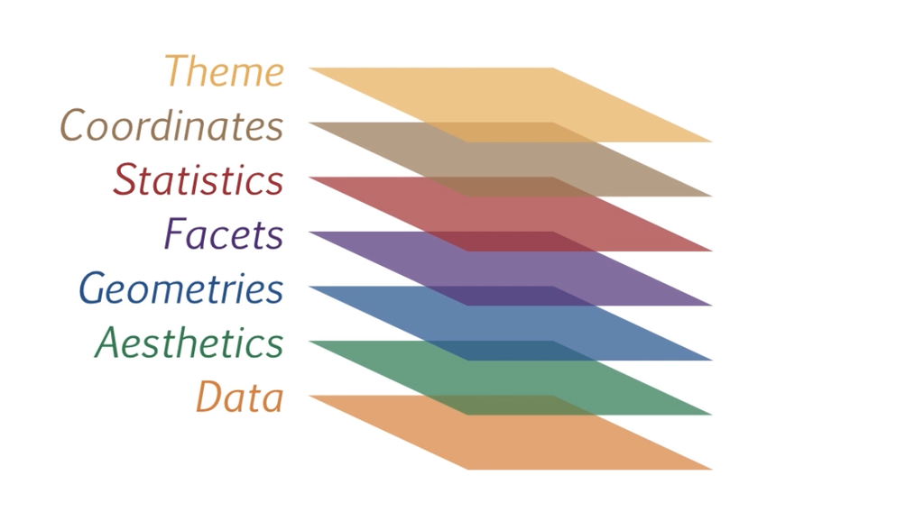

Data, aesthetics, and geometries are the three most basic layers you need to understand.

Aesthetics: * Axis * color, fill * size * opacity (alpha) * shape * line type

Geometries: * points * lines * bars * histogram * boxplot * etc.

Let’s see how this works with a basic plot. We’ll start with each element and add to it iteratively.

```r
# First add the data to the object
gg1 <- ggplot(df)
gg1

# then define how we want to map data on to the plot
gg1 <- gg1 + aes(x=petitioner_count)
gg1

# Finally we define the geometry we want the plot to take
gg1 <- gg1 + geom_bar()
gg1

# Now let's say we want to change the plot to a histogram, so we add the geom_histogram to our plot. What went wrong here?
gg1 <- gg1 + geom_histogram()
gg1

# The gg1 object already had a geom layer, and we added another one on top of it rather than replacing it.
```

[output not shown]

This is the basic idea, let’s do a more complicated example.

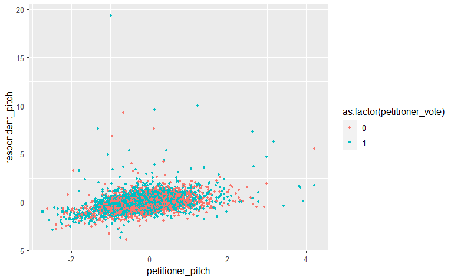

```r
ggplot(df) +
  aes(petitioner_pitch, respondent_pitch, color = as.factor(petitioner_vote)) +
  geom_point(shape = 20)
```

[figure not shown]

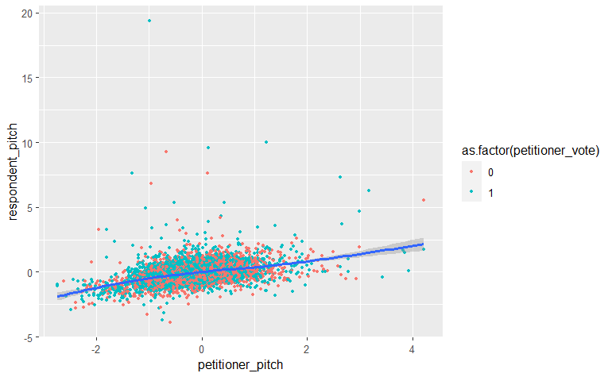

```r
# Move the color aesthetic to the point geometry
ggplot(df) +
  aes(petitioner_pitch, respondent_pitch) +
  geom_point(shape = 20,  aes(color = as.factor(petitioner_vote))) +
  geom_smooth()
```

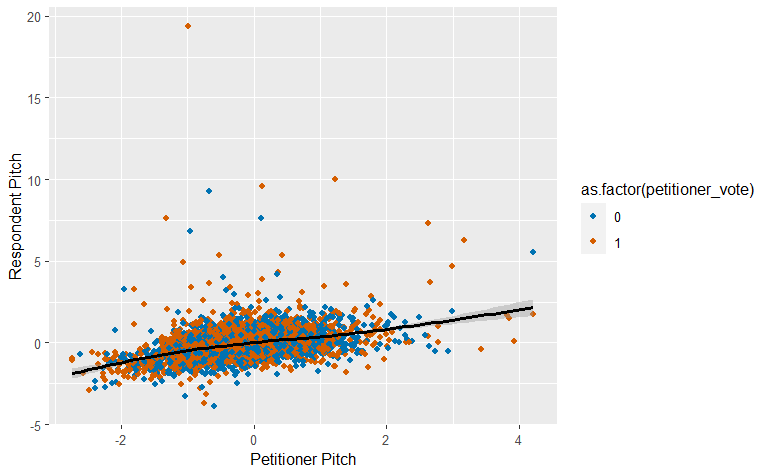

```r
ggplot(df) +
  aes(petitioner_pitch, respondent_pitch) +
  geom_point(shape = 19,  aes(color = as.factor(petitioner_vote))) +
  geom_smooth(color = 'black') +
  scale_color_manual(values = c('#0072b2', '#D55E00')) +
  xlab('Petitioner Pitch') +
  ylab('Respondent Pitch')
```

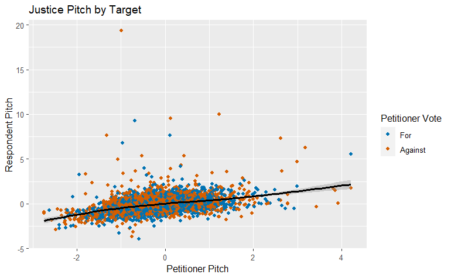

```r
# Now lets add some labels
ggplot(df) +
  aes(petitioner_pitch, respondent_pitch) +
  geom_point(shape = 19,  aes(color = as.factor(petitioner_vote))) +
  geom_smooth(color = 'black') +
  scale_color_manual("Petitioner Vote", values = c('#0072b2', '#D55E00'), labels = c('For', 'Against')) +
  xlab('Petitioner Pitch') +
  ylab('Respondent Pitch') +
  ggtitle('Justice Pitch by Target',)
```

[figure not shown]